# Good plot/ bad plot

Kassandra Jensen

2024-10-24

# Directions:

Due October 29

Create two version of similar plots, using any dataset you choose. You must create the plots using ggplot2, post-processing with Adobe Illustrator or similar is not allowed. Please submit your homework by posting a markdown document containing the plots, the code you used to create them, and your discussion of the plot within the markdown doc to github. Data also needs to be submitted.

# Load libraries

```r
library(tidyverse)
library(here)
```

# Load data

The data for this assignment came from the tidy tuesday posted on 12/19/2022. A link to the repository can be found [here](https://github.com/rfordatascience/tidytuesday/tree/master/data/2022/2022-12-20).

There are three separate data sheets that were downloaded from the repository, however only two were used in this assignment.

```r
weather_forecasts <- readr::read_csv('https://raw.githubusercontent.com/rfordatascience/tidytuesday/master/data/2022/2022-12-20/weather_forecasts.csv')
outlook_meanings <- readr::read_csv('https://raw.githubusercontent.com/rfordatascience/tidytuesday/master/data/2022/2022-12-20/outlook_meanings.csv')
glimpse(weather_forecasts)
```

```
## Rows: 651,968
## Columns: 10
## $ date                  <date> 2021-01-30, 2021-01-30, 2021-01-30, 2021-01-30,…
## $ city                  <chr> "ABILENE", "ABILENE", "ABILENE", "ABILENE", "ABI…
## $ state                 <chr> "TX", "TX", "TX", "TX", "TX", "TX", "TX", "TX", …
## $ high_or_low           <chr> "high", "high", "high", "high", "low", "low", "l…
## $ forecast_hours_before <dbl> 48, 36, 24, 12, 48, 36, 24, 12, 48, 36, 24, 12, …
## $ observed_temp         <dbl> 70, 70, 70, 70, 42, 42, 42, 42, 29, 29, 29, 29, …
## $ forecast_temp         <dbl> NA, NA, NA, 70, NA, NA, 39, 38, NA, NA, NA, 30, …
## $ observed_precip       <dbl> 0.00, 0.00, 0.00, 0.00, 0.00, 0.00, 0.00, 0.00, …
## $ forecast_outlook      <chr> NA, NA, NA, "DUST", NA, NA, "DUST", "SUNNY", NA,…
## $ possible_error        <chr> "none", "none", "none", "none", "none", "none", …
```

```r
glimpse(outlook_meanings)
```

```
## Rows: 23
## Columns: 2
## $ forecast_outlook <chr> "DUST", "SUNNY", "MOCLDY", "SNOW", "PTCLDY", "RAIN", …
## $ meaning          <chr> "Dust", "Sunny", "Mostly Cloudy", "Snow", "Partly Clo…
```

```r
## Saved data and uploaded to repository - do not need to keep saving
#write.csv(weather_forecasts, file = "weather_forecasts.csv", row.names = FALSE)
#write.csv(outlook_meanings, file = "outlook_meanings.csv", row.names = FALSE)
```

# Clean Data

```r
weather_forecasts_HI <- weather_forecasts%>%          ## Call data
  filter (state == "HI") %>%                          ## Only Hawai‘i
  drop_na(forecast_outlook)                           ## Get rid or NAs in column

## Check for which types of forecast outlooks there are
unique(weather_forecasts_HI$forecast_outlook)
```

```
## [1] "SHWRS"  "TSTRMS" "SUNNY"  "PTCLDY" "WINDY"  "MOCLDY" "CLOUDY"
```

```r
## Rename everything to unabbreviated name
weather_forecasts_HI <- weather_forecasts_HI %>%
  mutate(forecast_outlook = if_else(forecast_outlook == "SUNNY", "Sunny", forecast_outlook)) %>%
  mutate(forecast_outlook = if_else(forecast_outlook == "MOCLDY", "Mostly Cloudy", forecast_outlook))%>%
  mutate(forecast_outlook = if_else(forecast_outlook == "PTCLDY", "Partly Cloudy", forecast_outlook))%>%
  mutate(forecast_outlook = if_else(forecast_outlook == "SHWRS", "Rain Showers", forecast_outlook))%>%
  mutate(forecast_outlook = if_else(forecast_outlook == "CLOUDY", "Cloudy", forecast_outlook))%>%
  mutate(forecast_outlook = if_else(forecast_outlook == "WINDY", "Windy", forecast_outlook))%>%
  mutate(forecast_outlook = if_else(forecast_outlook == "TSTRMS", "Thunderstorms", forecast_outlook))
```

# Bad plot

## Data manipulation

```r
weather_forecasts_HI_counts<- weather_forecasts_HI %>%
  group_by(forecast_outlook) %>%
  summarise(count = n())

## View to make sure it's what I want
view(weather_forecasts_HI_counts)
```

##### This is a bad plot because:

- Missing key variables that make this data useful, like time or location
- Color are distracting
- Title does not explain subject of plot approriately
- Font size too big in plot and is being cut off
- Inappropriate use of emojis

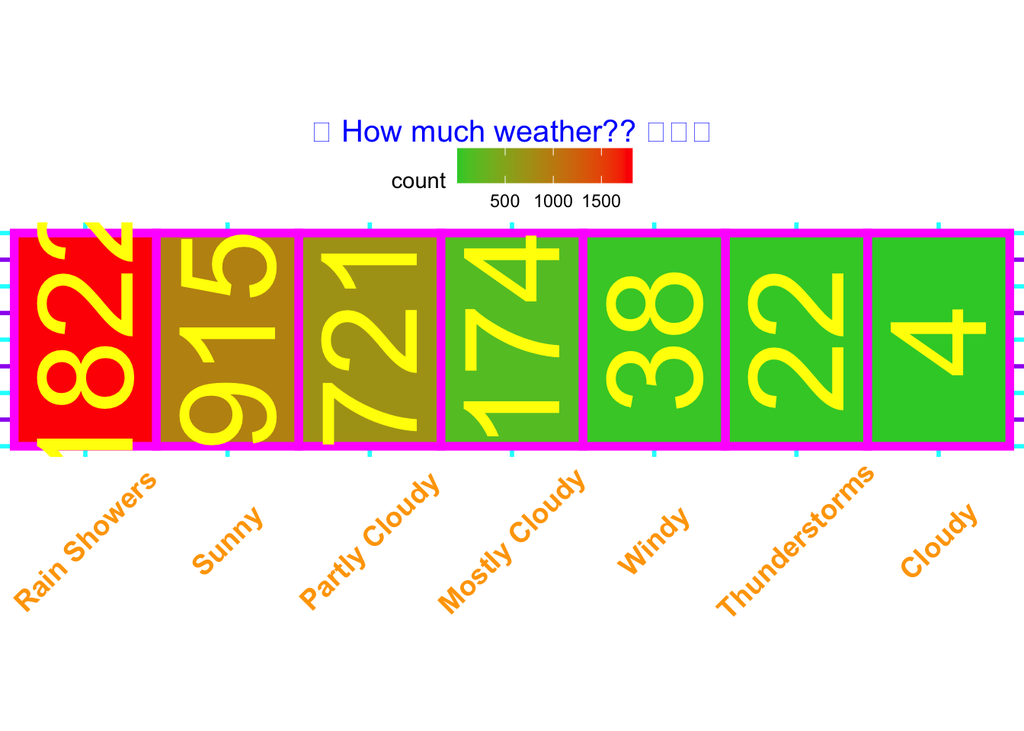

```r
ggplot(weather_forecasts_HI_counts, aes(x = reorder(forecast_outlook, -count), y = 1, fill = count)) +
  geom_tile(color = "magenta", size = 2) +
  geom_text(aes(label = count), size = 23, color = "yellow", angle = 90) +
  scale_fill_gradient(low = "limegreen", high = "red") +
  labs(title = expression(paste("😎 How much weather?? 🌧")),
                                x = "Forecast Outlook", y = "") +
  theme_void() +
  theme(
    plot.title = element_text(size = 15, face = "bold.italic", hjust = 0.5, color = "blue"),
    legend.position = "top",
    panel.grid.major = element_line(size = 1, color = "cyan"),
    panel.grid.minor = element_line(size = 1, color = "purple"),
    axis.text.x = element_text(size = 14, face = "bold", color = "orange", angle = 45)
  ) +
  coord_fixed(ratio = 1.5)
```

```r
ggsave(here("Good_plot_bad_plot","Output","badplot.png"))
```

# Good plot

### Data manipulation

```r
weather_forecasts_HI <- weather_forecasts_HI %>%   ## call data
  mutate(month_year = floor_date(date, "month"))   ## round data to nearest month

forecast_counts <- weather_forecasts_HI %>%        ## call data
  group_by(month_year, forecast_outlook) %>%       ## group by date and forecast because that's all we care about
  summarise(count = n()) %>%                       ## n() counts the unique observations of what I put in groupby()
  ungroup()
```

### Plot

##### This is a good plot because:

- Clear title and subtitle showcasing location and what the plot is trying to represent
- Helpful x and y-axis
- Appropriate font size
- Colors are not distracting and help convey denities
- Heat map conveys meaningful densities overtime for comparisons
- Data is sourced

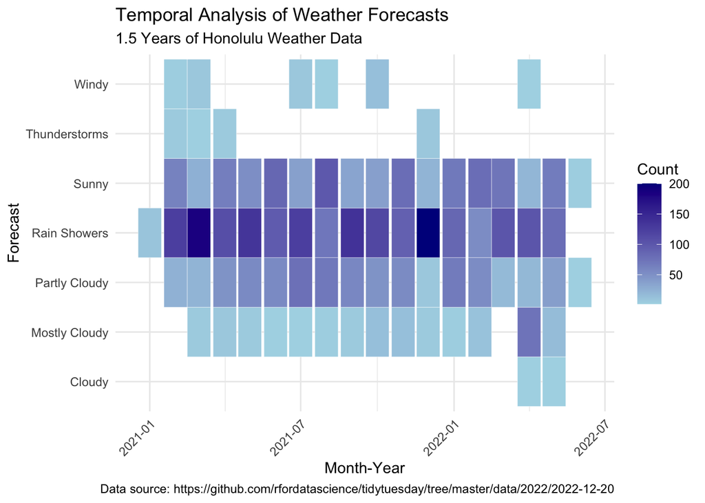

```r
ggplot(forecast_counts, aes(x = month_year,                             ## call data, put month_year as x axis
                            y = forecast_outlook)) +                    ## forecast as y- axis
  geom_tile(aes(fill = count), color = "white") +                       ## use geom_tile for heat map
  scale_fill_gradient(low = "lightblue", high = "darkblue") +           ## pretty colors
  labs(title = "Temporal Analysis of Weather Forecasts",                ## titles
       subtitle = "1.5 Years of Honolulu Weather Data",
       caption = "Data source: https://github.com/rfordatascience/tidytuesday/tree/master/data/2022/2022-12-20",
       x = "Month-Year",
       y = "Forecast",
       fill = "Count") +
  theme_minimal() +                                                     ## minimal theme
  theme(axis.text.x = element_text(angle = 45, hjust = 1))
```

```r
ggsave(here("Good_plot_bad_plot","Output","goodplot.png"))
```